# SAMN'S MERCADO: END TO END E-COMMERCE PLATFORM

LEARNING TEAM 3 - ASIS, ITUCAL, MERCADO, RIZADA

## Introduction

This project showcases the data engineering skills learned in the elective by developing **Samn's Mercado**, an e-commerce platform designed to enhance both customer experience and vendor operations.

The platform allows customers to browse and purchase a diverse selection of products while equipping vendors with a powerful analytics suite built on data lakes and data warehouses. By leveraging Data Science, Analytics, and AI (DSAI), vendors can track sales performance, extract actionable insights, and optimize their business strategies.

## Architecture Overview

### End to end system architecture:

[figure not shown]

### Docker Architecture:

[figure not shown]

Services are deployed via Docker in an EC2 instance for ease of deployment and easy to spin up and tear down. The architecture includes:

- **Postgres for OLTP**: Instead of using RDS, a Postgres instance is contained within the Docker network.
- **Airflow + Postgres**: For orchestration and workflow management.
- **JupyterLab Container**: To run inserts and provide DSAI use cases in consumption.

### Directory Structure

The project directory is organized as follows:

- `src` - source codes
  - `airflow` - airflow source codes
  - `api` - fastapi source codes
  - `dockerfiles` - Dockerfile definition for the services
  - `jupyterlab` - Notebooks and Images
  - `sql` - sql references for create tables
- `.github/workflows` - pre-commit hooks via github actions
- `sample_env` - sample env file to be filled up in an actual `.env file`, should specify details about connection details, and aws access keys.
- `.pre-commit-config.yaml` - pre-commit dependencies
- `docker-compose.yml` - docker compose definitions

## API Layer

In this layer we use the API endpoints served via FastAPI to:

- Submit customers
- Submit vendors
- Submit inventory of vendors
- Simulate customer adding to cart, checking out and leaving items in their carts

```python
%load_ext sql
```

```python
import boto3
import requests
import os
import pandas as pd
from sqlalchemy import create_engine
from faker import Faker
import redshift_connector
```

```python
import warnings
warnings.filterwarnings('ignore')
```

```python
pd.set_option('display.max_rows', 12)
pd.set_option('display.min_rows', 6)
```

We will use faker to submit dummy API requests based on the definitions above.

```python
fake = Faker()

base_url = "http://fastapi:8000"
headers = {"Content-Type": "application/json"}

print("customers")
# Create customers
for customer_id in range(1, 11):
    data = {
        "first_name": fake.first_name(),
        "last_name": fake.last_name(),
        "email": fake.email(),
        "joined_at": fake.iso8601()
    }
    response = requests.post(f"{base_url}/customers/", json=data, headers=headers)
    print(response.status_code, response.json())

print("vendors")
# Create vendors
for vendor_id in range(1, 6):
    data = {
        "vendor_name": fake.company(),
        "region": fake.country_code()
    }
    response = requests.post(f"{base_url}/vendors/", json=data, headers=headers)
    print(response.status_code, response.json())

print("inventory per vendor")
# Add inventory per vendor
for vendor_id in range(1, 6):
    for item_id in range(1, 11):
        params = {"vendor_id": vendor_id}
        data = {
            "item_name": fake.word(),
            "category": str(1),
            "price": fake.random_int(min=10, max=500),
        }
        response = requests.post(f"{base_url}/inventory/", json=data, headers=headers, params=params)
        print(response.status_code, response.json())

print("cart and checkout twice and add to cart again!")
for customer_id in range(1, 11):
    for _ in range(2):  # Checkout twice
        price1 = fake.random_int(min=10, max=500)
        price2 = fake.random_int(min=10, max=500)
        qty1 = fake.random_int(min=10, max=500)
        qty2 = fake.random_int(min=10, max=500)
        cart_data = {
            "user_id": customer_id,
            "cart": [
                {
                    "item_id": str(fake.random_int(min=1, max=10)),
                    "vendor_id": str(fake.random_int(min=1, max=5)),
                    "qty": qty1,
                    "unit_price": price1,
                    "total_price": qty1*price1,
                },
                {
                    "item_id": str(fake.random_int(min=1, max=10)),
                    "vendor_id": str(fake.random_int(min=1, max=5)),
                    "qty": qty2,
                    "unit_price": price2,
                    "total_price": qty2*price2,
                }
            ]
        }
        response = requests.post(f"{base_url}/cart/", json=cart_data, headers=headers)
        print(response.status_code, response.json())

        response = requests.post(f"{base_url}/checkout/", json={"user_id": customer_id}, headers=headers)
        print(response.status_code, response.text)

    price1 = fake.random_int(min=10, max=500)
    price2 = fake.random_int(min=10, max=500)
    qty1 = fake.random_int(min=10, max=500)
    qty2 = fake.random_int(min=10, max=500)
    # Add to cart one more time
    cart_data = {
        "user_id": customer_id,
        "cart": [
            {
                "item_id": str(fake.random_int(min=1, max=10)),
                "vendor_id": str(fake.random_int(min=1, max=5)),
                "qty": qty1,
                "unit_price": price1,
                "total_price": qty1*price1,
            },
            {
                "item_id": str(fake.random_int(min=1, max=10)),
                "vendor_id": str(fake.random_int(min=1, max=5)),
                "qty": qty1,
                "unit_price": price1,
                "total_price": qty1*price1,
            }
        ]
    }
    response = requests.post(f"{base_url}/cart/", json=cart_data, headers=headers)
    print(response.status_code, response.json())
```

```
customers
201 {'id': 1, 'first_name': 'Brandon', 'last_name': 'Sims', 'email': 'adrian49@example.com', 'joined_at': '2025-03-17T02:33:40.378808'}
201 {'id': 2, 'first_name': 'Ronald', 'last_name': 'Johnson', 'email': 'igarcia@example.org', 'joined_at': '2025-03-17T02:33:40.388027'}
201 {'id': 3, 'first_name': 'William', 'last_name': 'Bryant', 'email': 'bobby28@example.org', 'joined_at': '2025-03-17T02:33:40.396208'}
201 {'id': 4, 'first_name': 'Sarah', 'last_name': 'Roberts', 'email': 'wlopez@example.org', 'joined_at': '2025-03-17T02:33:40.403323'}
201 {'id': 5, 'first_name': 'Stacy', 'last_name': 'Riley', 'email': 'heather29@example.com', 'joined_at': '2025-03-17T02:33:40.411846'}
201 {'id': 6, 'first_name': 'Maria', 'last_name': 'Case', 'email': 'michaelrasmussen@example.net', 'joined_at': '2025-03-17T02:33:40.421316'}
201 {'id': 7, 'first_name': 'Barbara', 'last_name': 'James', 'email': 'scott38@example.com', 'joined_at': '2025-03-17T02:33:40.428812'}
201 {'id': 8, 'first_name': 'Joseph', 'last_name': 'Miller', 'email': 'nicolepreston@example.com', 'joined_at': '2025-03-17T02:33:40.437615'}
201 {'id': 9, 'first_name': 'Melissa', 'last_name': 'Thomas', 'email': 'carol19@example.com', 'joined_at': '2025-03-17T02:33:40.446074'}
201 {'id': 10, 'first_name': 'Roberta', 'last_name': 'Brown', 'email': 'lambertbryan@example.org', 'joined_at': '2025-03-17T02:33:40.456996'}
vendors
201 {'id': 1, 'vendor_name': 'Moyer-Vance', 'region': 'BZ', 'joined_at': '2025-03-17T02:33:40.466291'}
201 {'id': 2, 'vendor_name': 'Todd and Sons', 'region': 'MN', 'joined_at': '2025-03-17T02:33:40.475478'}
201 {'id': 3, 'vendor_name': 'Adams PLC', 'region': 'SZ', 'joined_at': '2025-03-17T02:33:40.482745'}
```

[output cut: 104 more lines]

```python
OLTP_USER = os.getenv("POSTGRES_USER")
OLTP_PASS = os.getenv("POSTGRES_PASSWORD")
OLTP_HOST = os.getenv("POSTGRES_HOST")
OLTP_DB_NAME = os.getenv("POSTGRES_DB")
OLAP_USER = os.getenv("REDSHIFT_USER")
OLAP_PASS = os.getenv("REDSHIFT_PASSWORD")
OLAP_HOST = os.getenv("REDSHIFT_HOST")
OLAP_DB_NAME = os.getenv("REDSHIFT_DB")
```

```python
connection_string = f"postgresql://{OLTP_USER}:{OLTP_PASS}@{OLTP_HOST}:5432/{OLTP_DB_NAME}"
engine = create_engine(connection_string)
get_ipython().run_line_magic('sql', connection_string)
```

Connecting to 'postgresql://user:***@db:5432/ecommerce'

## Viewing OLTP Layer - PostgreSQL and NoSQL

The OLTP layer comprises a **relational database (PostgreSQL)** and a **NoSQL database (DynamoDB)** to efficiently manage transactional data, including user accounts, orders, and payments.

### Postgres side

ERD:

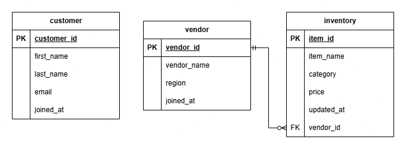

PostgreSQL is ideal for managing core entities in an e-commerce platform, such as customers, vendors, and product inventories.

**Customer-side benefits:**

- **Efficient product searches** using structured queries (e.g., searching by `item_name` or `vendor_name`).
- **Quick user lookups** by attributes like `email` or `first_name`, improving account and order management.

**Vendor-side benefits:**

- **Seamless vendor management**, allowing quick lookup of clients by client name or `email`.
- **Inventory tracking**, ensuring vendors can monitor stock levels and pricing in real time.

*Create table definition found in `src\sql\*` directory

```python
%sql \dt
```

Running query in 'postgresql://user:***@db:5432/ecommerce'

| Schema | Name | Type | Owner |
| --- | --- | --- | --- |
| public | customer | table | user |
| public | inventory | table | user |
| public | vendor | table | user |

```python
table_list = [
    "customer", "inventory", "vendor"
]
```

```python
for table in table_list:
    print(f"{table}")
    schema_query = f"columns --table {table}"
    display(get_ipython().run_line_magic('sqlcmd', schema_query))
```

```
customer
```

| name | type | nullable | default | autoincrement | comment |
| --- | --- | --- | --- | --- | --- |
| id | INTEGER | False | nextval('customer_id_seq'::regclass) | True | None |
| first_name | TEXT | False | None | False | None |
| last_name | TEXT | False | None | False | None |
| email | TEXT | False | None | False | None |
| joined_at | TIMESTAMP | False | None | False | None |

```
inventory
```

| name | type | nullable | default | autoincrement | comment |
| --- | --- | --- | --- | --- | --- |
| id | INTEGER | False | nextval('inventory_id_seq'::regclass) | True | None |
| item_name | TEXT | False | None | False | None |
| category | TEXT | False | None | False | None |
| price | INTEGER | False | None | False | None |
| updated_at | TIMESTAMP | False | None | False | None |
| vendor_id | INTEGER | True | None | False | None |

```
vendor
```

| name | type | nullable | default | autoincrement | comment |
| --- | --- | --- | --- | --- | --- |
| id | INTEGER | False | nextval('vendor_id_seq'::regclass) | True | None |
| vendor_name | TEXT | False | None | False | None |
| region | TEXT | False | None | False | None |
| joined_at | TIMESTAMP | False | None | False | None |

```python
for table in table_list:
    print(f"{table}")
    display(pd.read_sql(f"select * from {table} limit 100", engine.raw_connection()))
```

```
customer
```

|  | id | first_name | last_name | email | joined_at |
| --- | --- | --- | --- | --- | --- |
| 0 | 1 | Brandon | Sims | adrian49@example.com | 2025-03-17 02:33:40.378808 |
| 1 | 2 | Ronald | Johnson | igarcia@example.org | 2025-03-17 02:33:40.388027 |
| 2 | 3 | William | Bryant | bobby28@example.org | 2025-03-17 02:33:40.396208 |
| 3 | 4 | Sarah | Roberts | wlopez@example.org | 2025-03-17 02:33:40.403323 |
| 4 | 5 | Stacy | Riley | heather29@example.com | 2025-03-17 02:33:40.411846 |
| 5 | 6 | Maria | Case | michaelrasmussen@example.net | 2025-03-17 02:33:40.421316 |
| 6 | 7 | Barbara | James | scott38@example.com | 2025-03-17 02:33:40.428812 |
| 7 | 8 | Joseph | Miller | nicolepreston@example.com | 2025-03-17 02:33:40.437615 |
| 8 | 9 | Melissa | Thomas | carol19@example.com | 2025-03-17 02:33:40.446074 |
| 9 | 10 | Roberta | Brown | lambertbryan@example.org | 2025-03-17 02:33:40.456996 |

```
inventory
```

|  | id | item_name | category | price | updated_at | vendor_id |
| --- | --- | --- | --- | --- | --- | --- |
| 0 | 1 | necessary | 1 | 314 | 2025-03-17 02:33:40.508823 | 1 |
| 1 | 2 | consumer | 1 | 79 | 2025-03-17 02:33:40.517968 | 1 |
| 2 | 3 | begin | 1 | 334 | 2025-03-17 02:33:40.525865 | 1 |
| ... | ... | ... | ... | ... | ... | ... |
| 47 | 48 | section | 1 | 237 | 2025-03-17 02:33:40.912562 | 5 |
| 48 | 49 | popular | 1 | 124 | 2025-03-17 02:33:40.919968 | 5 |
| 49 | 50 | theory | 1 | 227 | 2025-03-17 02:33:40.926696 | 5 |

50 rows × 6 columns

```
vendor
```

|  | id | vendor_name | region | joined_at |
| --- | --- | --- | --- | --- |
| 0 | 1 | Moyer-Vance | BZ | 2025-03-17 02:33:40.466291 |
| 1 | 2 | Todd and Sons | MN | 2025-03-17 02:33:40.475478 |
| 2 | 3 | Adams PLC | SZ | 2025-03-17 02:33:40.482745 |
| 3 | 4 | Mendoza Ltd | BZ | 2025-03-17 02:33:40.490691 |
| 4 | 5 | Williams Inc | PS | 2025-03-17 02:33:40.498885 |

### DynamoDB side

ERD/Entity Containment in NoSQL:

[figure not shown]

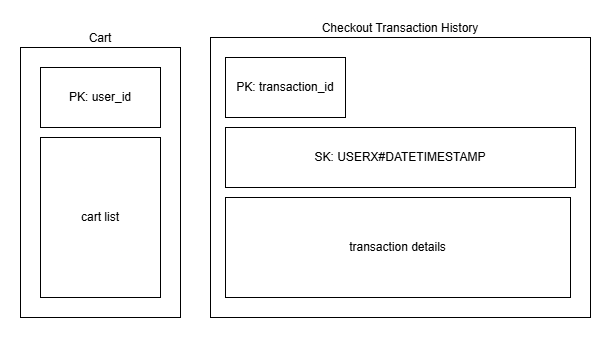

DynamoDB is chosen for handling **frequently changing data** such as shopping carts and transactions due to its **schema flexibility, high-performance read/write capabilities, and scalability**.

- The **Cart table** uses `user_id` as the **Partition Key (PK)**, allowing it to store a **nested list of items**, enabling **real-time updates** as users modify their carts.
- The **Transaction table** is structured with `transaction_id` as the **Partition Key (PK)** and `user_id#timestamp` as the **Sort Key (SK)**, ensuring **efficient lookups and chronological ordering** of transactions per user.

DynamoDB’s **scalability and low-latency access** make it an ideal choice for **real-time cart updates and seamless transaction history management**, ensuring a smooth and responsive shopping experience in a dynamic e-commerce environment.

```python
dynamodb = boto3.resource("dynamodb", "us-east-1")
table = dynamodb.Table("mercado_ecommerce")
table.scan()['Items'][:3]
```

```
[{'updated_at': '2025-03-17T02:33:41.460999',
  'sk': 'CART',
  'pk': 'USER#8',
  'cart': [{'unit_price': Decimal('20'),
    'total_price': Decimal('9540'),
    'item_id': '2',
    'qty': Decimal('477'),
    'vendor_id': '2'},
   {'unit_price': Decimal('20'),
    'total_price': Decimal('9540'),
    'item_id': '10',
    'qty': Decimal('477'),
    'vendor_id': '5'}]},
 {'sk': 'USER6#2025-03-17T02:33:41.331368',
  'created_at': '2025-03-17T02:33:41.331368',
  'pk': '170fdaaa-f2e6-4809-b42c-23357be591c3',
  'cart': [{'unit_price': Decimal('150'),
    'total_price': Decimal('56100'),
    'item_id': '1',
    'qty': Decimal('374'),
    'vendor_id': '5'},
   {'unit_price': Decimal('381'),
    'total_price': Decimal('68580'),
    'item_id': '7',
    'qty': Decimal('180'),
    'vendor_id': '3'}]},
 {'updated_at': '2025-03-17T02:33:41.099113',
  'sk': 'CART',
  'pk': 'USER#2',
  'cart': [{'unit_price': Decimal('151'),
    'total_price': Decimal('67950'),
    'item_id': '1',
    'qty': Decimal('450'),
    'vendor_id': '1'},
   {'unit_price': Decimal('151'),
    'total_price': Decimal('67950'),
    'item_id': '9',
    'qty': Decimal('450'),
    'vendor_id': '5'}]}]
```

## Worflow Management and Data Pipeline

This section outlines the **workflow deployed in Apache Airflow**.

**Processing Mode**

- The DAG operates in **batch processing mode**, running **daily** to ensure timely updates and maintain data consistency across the pipeline.

*DAG technical code definition found in `src\airflow\dags\*` directory

[figure not shown]

[figure not shown]

## Data Lake

### Storage Layer

[figure not shown]

The **data lake storage layer** is structured into four key zones—**raw, cleaned, work, and gold**—each serving a distinct role in the data processing pipeline.

1. **Raw Zone**
   - Acts as the **landing area** for unprocessed data.
   - Stores data **exactly as ingested** from various sources, preserving **data fidelity and traceability**.
2. **Cleaned Zone**
   - Contains data that has undergone **basic transformations**, including:
     - **Deduplication** to remove redundant entries.
     - **Format standardization** for consistency across datasets.
     - **Schema validation** to ensure structural integrity.
   - Prepares data for **further transformation and analysis**.
3. **Work Zone**
   - Serves as a **sandbox environment** for **analysts and data engineers**.
   - Used for **data transformations, enrichment, and exploratory analysis** before finalizing datasets.
4. **Gold Zone**
   - Stores **highly curated, business-ready datasets** optimized for:
     - **Analytics and reporting** for decision-making.
     - **Machine learning applications** requiring high data quality.
   - Ensures **data governance, compliance, and usability**.

S3 contents:

[figure not shown]

### RBAC - Role-Based Access Management

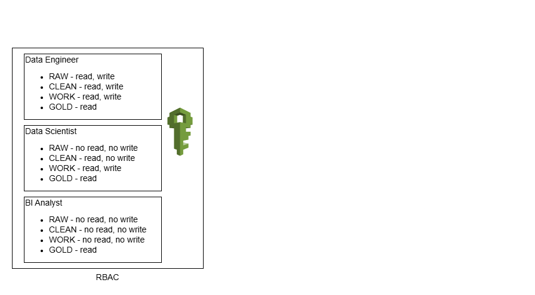

The **Role-Based Access Control (RBAC)** model is designed to enforce **data security, governance, and efficient collaboration** by granting appropriate permissions based on user roles within the data lake.

- **Data Engineers**
  - Have **full access** to ingest, clean, and prepare data.
  - Ensure **data quality and usability** across all zones.
- **Data Scientists**
  - Access **curated datasets** for analysis and modeling.
  - Can experiment in the **work zone** but **cannot modify raw or cleaned data**, preserving data integrity.
- **BI Analysts**
  - Restricted to **business-ready data** in the **gold zone**.
  - Ensures **data consistency in reporting** while preventing accidental modifications to upstream datasets.

This structure minimizes the risk of accidental data corruption while ensuring each role has the appropriate level of access for their tasks.

## Data Warehousing - Redshift

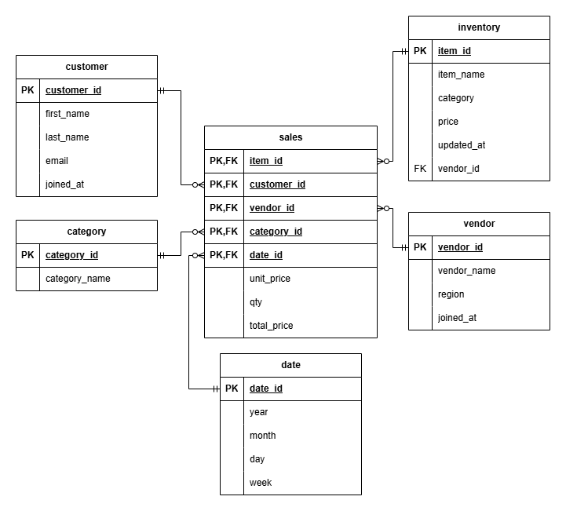

The **Entity-Relationship Diagram (ERD)** represents an **e-commerce sales fact table**, with each transaction line item serving as the **granularity** of the dataset.

**Supporting Dimension Tables**  
The fact table is connected to multiple **dimension tables**, providing contextual details for analytics:

- **`customer` dimension**
  - Stores customer-related data, enabling insights into **purchasing behavior and segmentation**.
- **`category` dimension**
  - Classifies products, supporting **sales performance analysis** across different product groups.
- **`date` dimension**
  - Facilitates **time-based reporting**, enabling trend analysis, seasonality insights, and forecasting.
- **`inventory` dimension**
  - Tracks stock levels, aiding in **supply chain efficiency** and inventory optimization.
- **`vendor` dimension**
  - Contains supplier details, helping assess **procurement efficiency and vendor performance**.

**Star Schema for Optimized Analytics**  
This **star schema design** enhances **query performance and scalability**, making it efficient for **business intelligence, reporting, and sales analysis** in an e-commerce environment.

```python
connection_string = f"postgresql://{OLAP_USER}:{OLAP_PASS}@{OLAP_HOST}:5439/{OLAP_DB_NAME}"
engine = redshift_connector.connect(
    host=OLAP_HOST,
    port=5439,
    database=OLAP_DB_NAME,
    user=OLAP_USER,
    password=OLAP_PASS
)
engine = create_engine(connection_string)
get_ipython().run_line_magic('sql', connection_string)
```

Connecting and switching to connection 'postgresql://vincent:***@samplecluster.cq68pg38qszs.us-east-1.redshift.amazonaws.com:5439/mercado_ecommerce'

*Create table definition found in `src\sql\*` directory

```python
%sql \dt
```

Running query in 'postgresql://vincent:***@samplecluster.cq68pg38qszs.us-east-1.redshift.amazonaws.com:5439/mercado_ecommerce'

| schema | name | type | owner |
| --- | --- | --- | --- |
| public | category | table | vincent |
| public | customer | table | vincent |
| public | date | table | vincent |
| public | inventory | table | vincent |
| public | sales | table | vincent |
| public | vendor | table | vincent |

```python
table_list = [
    "category", "customer", "date", "inventory", "vendor", "sales"
]
```

```python
for table in table_list:
    print(f"{table}")
    schema_query = f"columns --table {table}"
    display(get_ipython().run_line_magic('sqlcmd', schema_query))
```

```
category
```

| name | type | nullable | default | autoincrement | comment |
| --- | --- | --- | --- | --- | --- |
| category_id | INTEGER | False | None | False | None |
| category_name | VARCHAR(100) | True | None | False | None |

```
customer
```

| name | type | nullable | default | autoincrement | comment |
| --- | --- | --- | --- | --- | --- |
| customer_id | INTEGER | False | None | False | None |
| first_name | VARCHAR(50) | True | None | False | None |
| last_name | VARCHAR(50) | True | None | False | None |
| email | VARCHAR(100) | True | None | False | None |
| joined_at | TIMESTAMP | True | None | False | None |

```
date
```

| name | type | nullable | default | autoincrement | comment |
| --- | --- | --- | --- | --- | --- |
| date_id | INTEGER | False | None | False | None |
| year | INTEGER | True | None | False | None |
| month | INTEGER | True | None | False | None |
| day | INTEGER | True | None | False | None |

```
inventory
```

| name | type | nullable | default | autoincrement | comment |
| --- | --- | --- | --- | --- | --- |
| item_id | INTEGER | False | None | False | None |
| item_name | VARCHAR(100) | True | None | False | None |
| category | INTEGER | True | None | False | None |
| price | NUMERIC(10, 2) | True | None | False | None |
| updated_at | TIMESTAMP | True | None | False | None |
| vendor_id | INTEGER | True | None | False | None |

```
vendor
```

| name | type | nullable | default | autoincrement | comment |
| --- | --- | --- | --- | --- | --- |
| vendor_id | INTEGER | False | None | False | None |
| vendor_name | VARCHAR(100) | True | None | False | None |
| region | VARCHAR(100) | True | None | False | None |
| joined_at | TIMESTAMP | True | None | False | None |

```
sales
```

| name | type | nullable | default | autoincrement | comment |
| --- | --- | --- | --- | --- | --- |
| item_id | INTEGER | True | None | False | None |
| customer_id | INTEGER | True | None | False | None |
| vendor_id | INTEGER | True | None | False | None |
| category_id | INTEGER | True | None | False | None |
| date_id | INTEGER | True | None | False | None |
| unit_price | NUMERIC(10, 2) | True | None | False | None |
| qty | INTEGER | True | None | False | None |
| total_price | NUMERIC(10, 2) | True | None | False | None |

```python
for table in table_list:
    print(f"{table}")
    display(pd.read_sql(f"select * from {table} limit 100", engine.raw_connection()))
```

```
category
```

|  | category_id | category_name |
| --- | --- | --- |
| 0 | 1 | General |

```
customer
```

|  | customer_id | first_name | last_name | email | joined_at |
| --- | --- | --- | --- | --- | --- |
| 0 | 1 | Brandon | Sims | adrian49@example.com | 2025-03-17 02:33:40.378808 |
| 1 | 2 | Ronald | Johnson | igarcia@example.org | 2025-03-17 02:33:40.388027 |
| 2 | 3 | William | Bryant | bobby28@example.org | 2025-03-17 02:33:40.396208 |
| 3 | 4 | Sarah | Roberts | wlopez@example.org | 2025-03-17 02:33:40.403323 |
| 4 | 5 | Stacy | Riley | heather29@example.com | 2025-03-17 02:33:40.411846 |
| 5 | 6 | Maria | Case | michaelrasmussen@example.net | 2025-03-17 02:33:40.421316 |
| 6 | 7 | Barbara | James | scott38@example.com | 2025-03-17 02:33:40.428812 |
| 7 | 8 | Joseph | Miller | nicolepreston@example.com | 2025-03-17 02:33:40.437615 |
| 8 | 9 | Melissa | Thomas | carol19@example.com | 2025-03-17 02:33:40.446074 |
| 9 | 10 | Roberta | Brown | lambertbryan@example.org | 2025-03-17 02:33:40.456996 |

```
date
```

|  | date_id | year | month | day |
| --- | --- | --- | --- | --- |
| 0 | 20250317 | 2025 | 3 | 17 |

```
inventory
```

|  | item_id | item_name | category | price | updated_at | vendor_id |
| --- | --- | --- | --- | --- | --- | --- |
| 0 | 1 | necessary | 1 | 314.0 | 2025-03-17 02:33:40.508823 | 1 |
| 1 | 2 | consumer | 1 | 79.0 | 2025-03-17 02:33:40.517968 | 1 |
| 2 | 3 | begin | 1 | 334.0 | 2025-03-17 02:33:40.525865 | 1 |
| ... | ... | ... | ... | ... | ... | ... |
| 47 | 48 | section | 1 | 237.0 | 2025-03-17 02:33:40.912562 | 5 |
| 48 | 49 | popular | 1 | 124.0 | 2025-03-17 02:33:40.919968 | 5 |
| 49 | 50 | theory | 1 | 227.0 | 2025-03-17 02:33:40.926696 | 5 |

50 rows × 6 columns

```
vendor
```

|  | vendor_id | vendor_name | region | joined_at |
| --- | --- | --- | --- | --- |
| 0 | 1 | Moyer-Vance | BZ | 2025-03-17 02:33:40.466291 |
| 1 | 2 | Todd and Sons | MN | 2025-03-17 02:33:40.475478 |
| 2 | 3 | Adams PLC | SZ | 2025-03-17 02:33:40.482745 |
| 3 | 4 | Mendoza Ltd | BZ | 2025-03-17 02:33:40.490691 |
| 4 | 5 | Williams Inc | PS | 2025-03-17 02:33:40.498885 |

```
sales
```

|  | item_id | customer_id | vendor_id | category_id | date_id | unit_price | qty | total_price |
| --- | --- | --- | --- | --- | --- | --- | --- | --- |
| 0 | 1 | 6 | 5 | 1 | 20250317 | 150.0 | 374 | 56100.0 |
| 1 | 7 | 6 | 3 | 1 | 20250317 | 381.0 | 180 | 68580.0 |
| 2 | 4 | 9 | 2 | 1 | 20250317 | 306.0 | 29 | 8874.0 |
| ... | ... | ... | ... | ... | ... | ... | ... | ... |
| 37 | 9 | 4 | 2 | 1 | 20250317 | 372.0 | 65 | 24180.0 |
| 38 | 1 | 10 | 1 | 1 | 20250317 | 129.0 | 53 | 6837.0 |
| 39 | 2 | 10 | 4 | 1 | 20250317 | 290.0 | 428 | 124120.0 |

40 rows × 8 columns

## Consumption Layer

Below we explore some options in consuming the data on our created Data Lake and Warehoure

### Read from Data Lake

We can read files from the data lake in this very notebook

```python
pd.read_csv("s3://mercado-ecommerce/raw/sales/20250317/sales.csv").head()
```

|  | item_id | customer_id | vendor_id | category_id | date_id | unit_price | qty | total_price |
| --- | --- | --- | --- | --- | --- | --- | --- | --- |
| 0 | 1 | 6 | 5 | 1 | 20250317 | 150.0 | 374.0 | 56100.0 |
| 1 | 7 | 6 | 3 | 1 | 20250317 | 381.0 | 180.0 | 68580.0 |
| 2 | 4 | 9 | 2 | 1 | 20250317 | 306.0 | 29.0 | 8874.0 |
| 3 | 2 | 9 | 3 | 1 | 20250317 | 52.0 | 21.0 | 1092.0 |
| 4 | 3 | 5 | 4 | 1 | 20250317 | 247.0 | 291.0 | 71877.0 |

### Read from Data Warehouse

We can also consume the data warehouse tables

```python
%%sql
SELECT
    i.item_name,
    c.first_name,
    c.last_name,
    v.vendor_name,
    cat.category_name,
    d.year,
    d.month,
    d.day,
    s.unit_price,
    s.qty,
    s.total_price
FROM sales s
INNER JOIN inventory i
    ON i.item_id = s.item_id
INNER JOIN customer c
    ON c.customer_id = s.customer_id
INNER JOIN vendor v
    ON v.vendor_id = s.vendor_id
INNER JOIN category cat
    ON cat.category_id = s.category_id
INNER JOIN date d
    ON d.date_id = s.date_id
```

Running query in 'postgresql://vincent:***@samplecluster.cq68pg38qszs.us-east-1.redshift.amazonaws.com:5439/mercado_ecommerce'

40 rows affected.

| item_name | first_name | last_name | vendor_name | category_name | year | month | day | unit_price | qty | total_price |
| --- | --- | --- | --- | --- | --- | --- | --- | --- | --- | --- |
| necessary | Maria | Case | Williams Inc | General | 2025 | 3 | 17 | 150.00 | 374 | 56100.00 |
| board | Maria | Case | Adams PLC | General | 2025 | 3 | 17 | 381.00 | 180 | 68580.00 |
| already | Melissa | Thomas | Todd and Sons | General | 2025 | 3 | 17 | 306.00 | 29 | 8874.00 |
| consumer | Melissa | Thomas | Adams PLC | General | 2025 | 3 | 17 | 52.00 | 21 | 1092.00 |
| begin | Stacy | Riley | Mendoza Ltd | General | 2025 | 3 | 17 | 247.00 | 291 | 71877.00 |
| window | Stacy | Riley | Adams PLC | General | 2025 | 3 | 17 | 98.00 | 363 | 35574.00 |
| service | Brandon | Sims | Adams PLC | General | 2025 | 3 | 17 | 12.00 | 182 | 2184.00 |
| charge | Brandon | Sims | Moyer-Vance | General | 2025 | 3 | 17 | 392.00 | 162 | 63504.00 |
| board | Melissa | Thomas | Adams PLC | General | 2025 | 3 | 17 | 413.00 | 340 | 140420.00 |
| agent | Melissa | Thomas | Williams Inc | General | 2025 | 3 | 17 | 392.00 | 310 | 121520.00 |

Truncated to displaylimit of 10.

## Summary: End-to-End E-Commerce System Implementation

This implementation of **Samn's Mercado** showcases a complete **end-to-end e-commerce architecture**, covering essential components:

- **API Layer** – Handles communication between frontend, backend, and external services.
- **OLTP Layer (SQL & NoSQL)** – Manages transactional data using **PostgreSQL** and **DynamoDB** for structured and flexible storage.
- **Workflow Management & Data Pipelines** – Automates data extraction, transformation, and loading (ETL) using **Apache Airflow**.
- **Data Lake Zones & Role-Based Access Control (RBAC)** – Organizes data into **raw, cleaned, work, and gold zones** while enforcing security and governance.
- **Data Warehousing & Dimensional Modeling** – Structures data efficiently in **Amazon Redshift**, enabling analytics and business intelligence.

**Scalability, Flexibility, and Business Insights**  
By integrating **Docker, AWS services, and Apache Airflow**, **Samn's Mercado** ensures:  
✅ **Scalability** – Adapts to growing business demands.  
✅ **Flexibility** – Supports a hybrid SQL & NoSQL architecture.  
✅ **Security** – Implements robust access controls and governance policies.

With this architecture, the platform **empowers vendors** with **advanced analytics and data-driven decision-making**, optimizing business operations for **enhanced performance and growth**.